# Assignment3_Part2

Suryoday T. Roy

January 27, 2018

```r
library(caret)
data("GermanCredit")
GC<-GermanCredit
head(GC,1)
```

```
##   Duration Amount InstallmentRatePercentage ResidenceDuration Age
## 1        6   1169                         4                 4  67
##   NumberExistingCredits NumberPeopleMaintenance Telephone ForeignWorker
## 1                     2                       1         0             1
##   Class CheckingAccountStatus.lt.0 CheckingAccountStatus.0.to.200
## 1  Good                          1                              0
##   CheckingAccountStatus.gt.200 CheckingAccountStatus.none
## 1                            0                          0
##   CreditHistory.NoCredit.AllPaid CreditHistory.ThisBank.AllPaid
## 1                              0                              0
##   CreditHistory.PaidDuly CreditHistory.Delay CreditHistory.Critical
## 1                      0                   0                      1
##   Purpose.NewCar Purpose.UsedCar Purpose.Furniture.Equipment
## 1              0               0                           0
##   Purpose.Radio.Television Purpose.DomesticAppliance Purpose.Repairs
## 1                        1                         0               0
##   Purpose.Education Purpose.Vacation Purpose.Retraining Purpose.Business
## 1                 0                0                  0                0
##   Purpose.Other SavingsAccountBonds.lt.100 SavingsAccountBonds.100.to.500
## 1             0                          0                              0
##   SavingsAccountBonds.500.to.1000 SavingsAccountBonds.gt.1000
## 1                               0                           0
##   SavingsAccountBonds.Unknown EmploymentDuration.lt.1
## 1                           1                       0
##   EmploymentDuration.1.to.4 EmploymentDuration.4.to.7
## 1                         0                         0
##   EmploymentDuration.gt.7 EmploymentDuration.Unemployed
## 1                       1                             0
##   Personal.Male.Divorced.Seperated Personal.Female.NotSingle
## 1                                0                         0
##   Personal.Male.Single Personal.Male.Married.Widowed
## 1                    1                             0
##   Personal.Female.Single OtherDebtorsGuarantors.None
## 1                      0                           1
##   OtherDebtorsGuarantors.CoApplicant OtherDebtorsGuarantors.Guarantor
## 1                                  0                                0
##   Property.RealEstate Property.Insurance Property.CarOther
## 1                   1                  0                 0
##   Property.Unknown OtherInstallmentPlans.Bank OtherInstallmentPlans.Stores
## 1                0                          0                            0
##   OtherInstallmentPlans.None Housing.Rent Housing.Own Housing.ForFree
## 1                          1            0           1               0
##   Job.UnemployedUnskilled Job.UnskilledResident Job.SkilledEmployee
## 1                       0                     0                   1
##   Job.Management.SelfEmp.HighlyQualified
## 1                                      0
```

### Q1 & 2

#### Selecting only Numeric Variables:

```r
GC<-GC[,1:7]
head(GC,1)
```

```
##   Duration Amount InstallmentRatePercentage ResidenceDuration Age
## 1        6   1169                         4                 4  67
##   NumberExistingCredits NumberPeopleMaintenance
## 1                     2                       1
```

#### Split Train and Test Data:

```r
set.seed(10001)
ind <- sample(c(TRUE, FALSE), nrow(GC), replace=TRUE, prob=c(0.632, 0.368))
data1 <- GC[ind, ]
data2<-GC[!ind,]
dataTrain<-as.data.frame(scale(data1))
```

#### Scaling Data for Train & using Train means,sd for scaling test

```r
means<-colMeans(data1)
sds<-c()
for (i in 1:ncol(data1)){
  sds[i]<-sd(data1[,i])
}
for (i in 1:nrow(data2)){
  for (j in 1:ncol(data2)){
    data2[i,j]<- (data2[i,j]-means[j])/sds[j]
  }
}
dataTest<-as.data.frame(data2)
```

#### Principal Components Analysis

```r
PCAObj<-princomp(dataTrain)
PCAObj$loadings
```

```
##
## Loadings:
##                           Comp.1 Comp.2 Comp.3 Comp.4 Comp.5 Comp.6 Comp.7
## Duration                  -0.653        -0.308  0.247                0.637
## Amount                    -0.715                                    -0.689
## InstallmentRatePercentage  0.245  0.181 -0.734  0.488  0.143        -0.332
## ResidenceDuration                 0.535 -0.144 -0.520  0.227  0.609
## Age                               0.622        -0.212        -0.747
## NumberExistingCredits             0.449  0.218  0.351 -0.755  0.237
## NumberPeopleMaintenance           0.290  0.545  0.508  0.592
##
##                Comp.1 Comp.2 Comp.3 Comp.4 Comp.5 Comp.6 Comp.7
## SS loadings     1.000  1.000  1.000  1.000  1.000  1.000  1.000
## Proportion Var  0.143  0.143  0.143  0.143  0.143  0.143  0.143
## Cumulative Var  0.143  0.286  0.429  0.571  0.714  0.857  1.000
```

```r
PCAObj$scores[1:5,]
```

```
##        Comp.1     Comp.2      Comp.3      Comp.4     Comp.5     Comp.6
## 1   1.6968951  2.7377561 -0.55930374 -0.78132958 -0.6519689 -1.2222944
## 3   0.5128955  1.0085231  1.94196956  0.08890678  1.8620810 -0.7951673
## 6  -2.6854646  0.9838668  1.29813493  0.21447575  2.0120539  0.6361449
## 11  0.9014936 -1.9734748  0.08229443  0.50502190 -0.1459492 -0.5076101
## 15  0.5082336 -0.4813700  0.25192044 -1.34602572  0.3683706  0.9437784
##         Comp.7
## 1  -0.33049030
## 3   0.07431688
## 6  -0.50217458
## 11 -0.05803004
## 15  0.38999839
```

### Q3 Scree Plots:

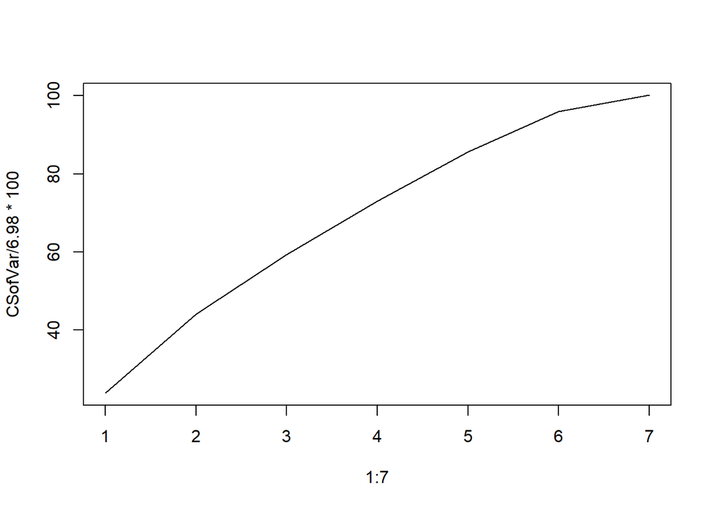

```r
V<-PCAObj$sdev^2
CSofVar<-cumsum(V)
plot(1:7,CSofVar/6.98*100,type='l')
```

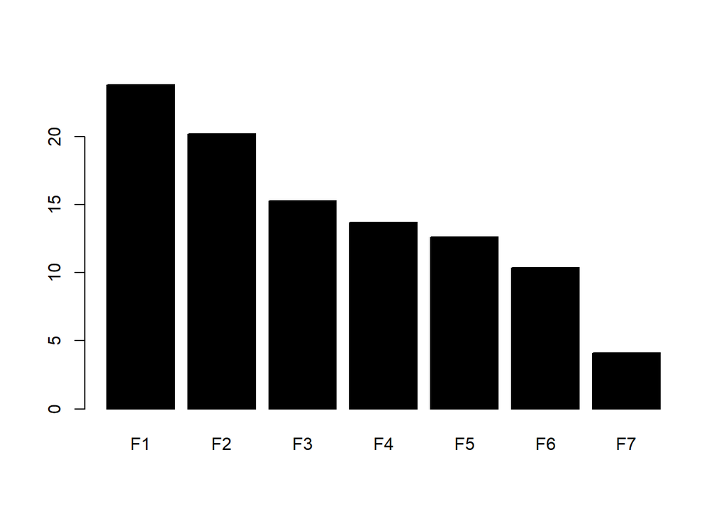

```r
barplot(PCAObj$sdev^2/sum(PCAObj$sdev^2)*100,width=2,col = "black",
        names.arg=c("F1","F2","F3","F4","F5","F6","F7"))
```

#### Based on the bar plot and scree plot, we can see that at n=5, more than 80% of the variance is accounted for and the remaining benefit may be cost prohibitive thus we can select n=5 as the number of factors to be retained.

### Q4. Plotting F1 against F2,3..5

```r
L<-PCAObj$loadings[,1:5]
L
```

```
##                                 Comp.1     Comp.2      Comp.3      Comp.4
## Duration                  -0.652844428 0.07892517 -0.30813641  0.24742116
## Amount                    -0.714773446 0.04115253  0.02662201 -0.06575415
## InstallmentRatePercentage  0.244637208 0.18095945 -0.73351284  0.48800289
## ResidenceDuration          0.002903712 0.53532622 -0.14428140 -0.51957676
## Age                        0.037448847 0.62212522 -0.03619417 -0.21193803
## NumberExistingCredits      0.036932983 0.44914116  0.21786783  0.35077771
## NumberPeopleMaintenance   -0.016456522 0.28980898  0.54470964  0.50832036
##                                Comp.5
## Duration                   0.05845905
## Amount                    -0.05471056
## InstallmentRatePercentage  0.14291738
## ResidenceDuration          0.22697998
## Age                        0.02855293
## NumberExistingCredits     -0.75505494
## NumberPeopleMaintenance    0.59221684
```

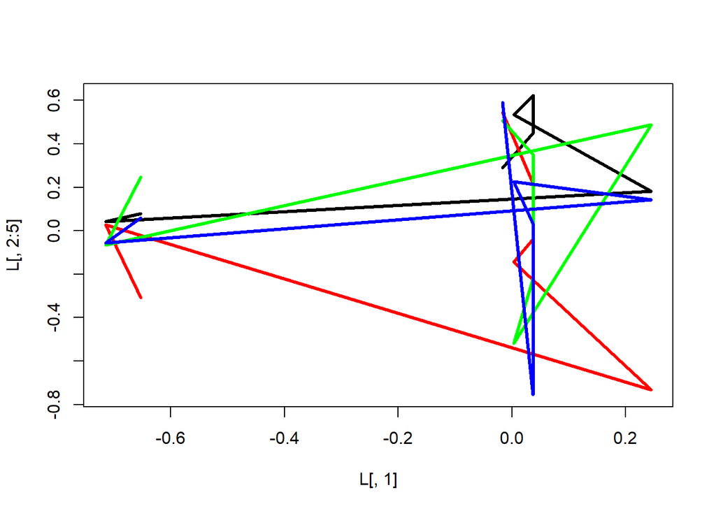

```r
matplot(L[,1],L[,2:5],type="l",lty=1,col=c("black","red","green","blue"),lwd=3)
```

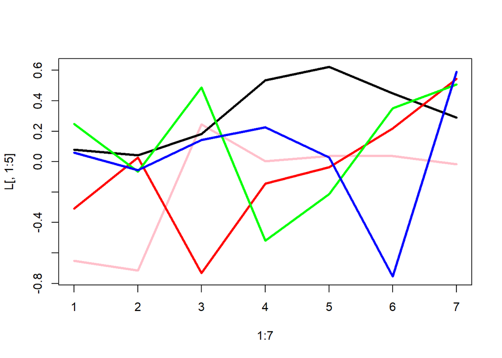

```r
matplot(1:7,L[,1:5],type="l",lty=1,col=c("pink","black","red","green","blue"),lwd=3)
```

Factor1: It has a negative effect for first two predictors, positive for the third and with near zero for the remaining 4. This will lead to a net tilt effect in the linear combination. Thus it penalizes amount of credit and duration of loan while slightly rewarding a good installment coverage %. It can be thought of as penalty for existing debt.

Factor 2: This has an apreciable positive loading for 3 factors and is approximately parallel for most predictors other than Age and Residence Duration. Its mode of shift would be a parallel shift upward. It has a positive correlation with Factor 1 and complements its effect. It is a factor that rewards age and stability(can be considered as a positive reinforcement to well settled customers)

Factor 3: This factor has a negative slope against Factor1 for most predictors and counteracts its effect. in all it crosses the 0 line multiple times and will have a bow-like mode of shift.Most notably it penalizes a high installment ratio and rewards number of dependents.

Factor 4: this factor counteracts the effects of Factor 3 and can be seen as a counter balance to the effect of Factor 3.Thus it has a positive relation with factor 1 and will have an opposite bow mode of shift as compared to Factor 3.

Factor 5: This factor most notably affects only two parameters viz. it penalizes existing credits and rewards number of dependents. This Factor will also have a tilt mode of shift as its effect as its impact on other factors is negligible. It counters Factor 1 for some factors while reinforces for others, balancing all other factors.

### Q5. Show Component loadings are orthogonal:

```r
Lfull<-PCAObj$loadings
m<-Lfull%*%t(Lfull)
for (i in 1:7){
  for(j in 1:7){
    if(m[i,j]< 0.00001){
      m[i,j]<-0
  }
}
}
m
```

```
##                           Duration Amount InstallmentRatePercentage
## Duration                         1      0                         0
## Amount                           0      1                         0
## InstallmentRatePercentage        0      0                         1
## ResidenceDuration                0      0                         0
## Age                              0      0                         0
## NumberExistingCredits            0      0                         0
## NumberPeopleMaintenance          0      0                         0
##                           ResidenceDuration Age NumberExistingCredits
## Duration                                  0   0                     0
## Amount                                    0   0                     0
## InstallmentRatePercentage                 0   0                     0
## ResidenceDuration                         1   0                     0
## Age                                       0   1                     0
## NumberExistingCredits                     0   0                     1
## NumberPeopleMaintenance                   0   0                     0
##                           NumberPeopleMaintenance
## Duration                                        0
## Amount                                          0
## InstallmentRatePercentage                       0
## ResidenceDuration                               0
## Age                                             0
## NumberExistingCredits                           0
## NumberPeopleMaintenance                         1
```

#### Since the dot product L’L is an Identity matrix, it proves that the component loadings are orthogonal.

### Q6. Show Component scores are orthogonal

```r
F<-PCAObj$scores
n<-t(F)%*%F
for (i in 1:nrow(n)){
  for(j in 1:ncol(n)){
    if(n[i,j]< 0.001){
      n[i,j]<-0
  }
}
}
n
```

```
##          Comp.1   Comp.2   Comp.3   Comp.4  Comp.5   Comp.6   Comp.7
## Comp.1 1059.346   0.0000   0.0000   0.0000   0.000   0.0000   0.0000
## Comp.2    0.000 897.9656   0.0000   0.0000   0.000   0.0000   0.0000
## Comp.3    0.000   0.0000 680.6085   0.0000   0.000   0.0000   0.0000
## Comp.4    0.000   0.0000   0.0000 609.3614   0.000   0.0000   0.0000
## Comp.5    0.000   0.0000   0.0000   0.0000 561.617   0.0000   0.0000
## Comp.6    0.000   0.0000   0.0000   0.0000   0.000 460.9062   0.0000
## Comp.7    0.000   0.0000   0.0000   0.0000   0.000   0.0000 182.1952
```

#### As all non diagonal elements are zero, it is again proven that all factor scores are perpendicular to each other.

### Q7& 8 Holdout testing

```r
Ftest<-predict(PCAObj,newdata = dataTest)
Dtest<-Ftest%*%t(Lfull)
round(cor(Dtest,dataTest)^2,2)
```

```
##                           Duration Amount InstallmentRatePercentage
## Duration                      1.00   0.38                      0.01
## Amount                        0.38   1.00                      0.07
## InstallmentRatePercentage     0.01   0.07                      1.00
## ResidenceDuration             0.00   0.00                      0.00
## Age                           0.00   0.00                      0.00
## NumberExistingCredits         0.00   0.00                      0.00
## NumberPeopleMaintenance       0.01   0.00                      0.02
##                           ResidenceDuration  Age NumberExistingCredits
## Duration                               0.00 0.00                  0.00
## Amount                                 0.00 0.00                  0.00
## InstallmentRatePercentage              0.00 0.00                  0.00
## ResidenceDuration                      1.00 0.08                  0.01
## Age                                    0.08 1.00                  0.01
## NumberExistingCredits                  0.01 0.01                  1.00
## NumberPeopleMaintenance                0.00 0.02                  0.01
##                           NumberPeopleMaintenance
## Duration                                     0.01
## Amount                                       0.00
## InstallmentRatePercentage                    0.02
## ResidenceDuration                            0.00
## Age                                          0.02
## NumberExistingCredits                        0.01
## NumberPeopleMaintenance                      1.00
```

All the diagonal elemnts being 1, it shows a perfect correlation between the computed testdata and the holdout sample